# methods bpow

Aurore A. Maureaud

2022

# Data input

- Marine Ecoregions of the World: 232 ecoregions, 62 provinces, and 12 realms, [Spalding et al., 2007](https://doi.org/10.1641/B570707) (Spalding et al. 2007)
- Deep sea GOODS provinces: 14 bathyal and 14 abyssal provinces [Watling et al., 2013](https://doi.org/10.1016/j.pocean.2012.11.003) (Watling et al. 2013)
- Hadal provinces [Belyaev, 1989](https://escholarship.org/uc/item/46n6148x) (Belyaev 1989)
- Global depth raster from [GEBCO](https://www.gebco.net/) (Group 2020)

# Analysis steps

## Part 1: check validity of DSP geometries

- Step #1: Both the bathyal and abyssal layers were checked because we noticed some wrong geometries in it when trying to perform geometric operations on Arc/QGIS. A lot of points were identified with wrong geometries because of self-intersections.

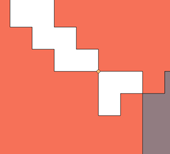

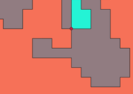

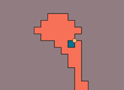

- Step #2: The validity of geometries was checked with the command “Check validity” of QGIS `Vector → Geometry Tools → Check Validity → Input Layer: BATHYAL/ABYSSAL`

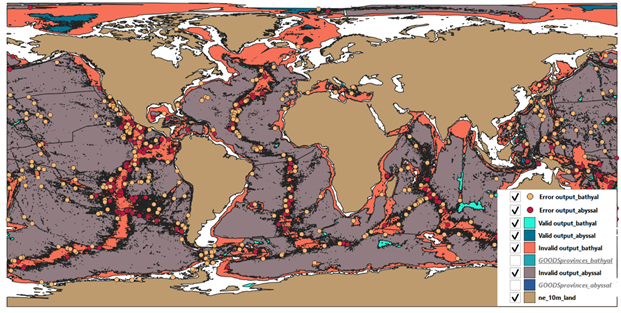

## Part 2: correcting geometries for the DSP shapefile layers

- Step #1: check validity of geometries on R with the sf function `st_is_valid()`to check what geometric problem is occurring. All issues are due to self-intersections on both objects
- Step #2: correct the geometric issues in both layers with the sf R function `st_make_valid()`
- Step #3: files saved with the function with the sf R function `st_write()`

```r
# load libraries
library(sf)
library(tidyverse)
library(ggplot2)
library(raster)
library(exactextractr)
library(rgdal)
library(fasterize)
sf::sf_use_s2(FALSE)
library(polyclip)
library(tiff)
library(raster)
library(geosphere)
library(fasterize)
library(smoothie)
library(exactextractr)


### Abyssal & Bathyal provinces from Watling et al., 2013
### Related publication: https://www.sciencedirect.com/science/article/abs/pii/S0079661112001693?via%3Dihub
### Access to shapefiles given by the author
abyssal <- st_read(dsn = "data/goods_provinces", layer = "GOODSprovinces_abyssal")
bathyal <- st_read(dsn = "data/goods_provinces", layer = "GOODSprovinces_bathyal")


### A. Work on abyssal self intersections
abyssal_validation <- st_is_valid(abyssal, reason=TRUE, NA_on_exception = FALSE)
View(abyssal_validation) # 189 abyssal with self-ring intersection

abyssal_corrected <- st_make_valid(abyssal)

abyssal_validation2 <- st_is_valid(abyssal_corrected, reason=TRUE, NA_on_exception = FALSE)
unique(abyssal_validation2) # all valid geometries


### B. Work on bathyal self intersections
bathyal_validation <- st_is_valid(bathyal, reason=TRUE, NA_on_exception = FALSE)
View(bathyal_validation) # 341 bathyal with self-ring intersection

bathyal_corrected <- st_make_valid(bathyal)

bathyal_validation2 <- st_is_valid(bathyal_corrected, reason=TRUE, NA_on_exception = FALSE)
unique(bathyal_validation2) # all valid geometries


### C. Save new files
st_write(abyssal_corrected, dsn = "outputs/deep_sea/GOODSprovinces_abyssal_Rfix.shp")
st_write(bathyal_corrected, dsn = "outputs/deep_sea/GOODSprovinces_bathyal_Rfix.shp")
```

## Part 3: Removing irregularities from the bathyal shapefile

- Step #1: identification of areas: off the Florida coast, because the threshold of 800m is arbitrary and this is a “transition” zone

[figure not shown]

- Step #2: fixed on R, using GEBCO and adding additional areas to the bathyal layer
- Step #3: all polygons intersecting the depth raster (in blue below) are merged via `st_union()` to create one larger replacing polygons, added to the bathyal layer

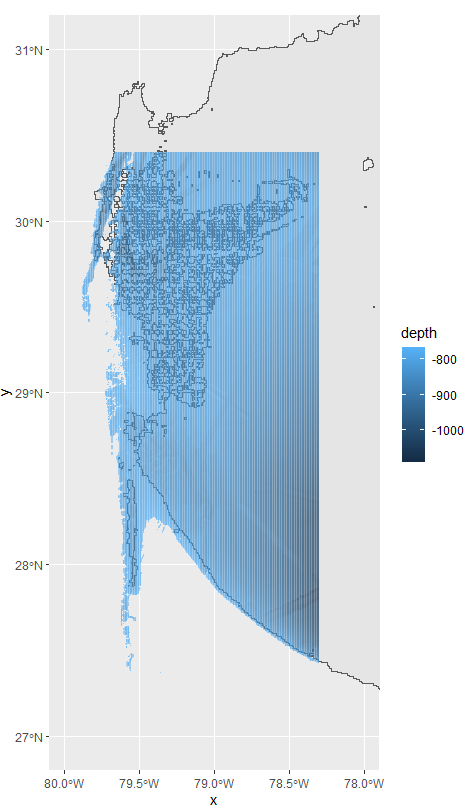

- Step #4: geometry checked again and file saved with the function with the sf R function`st_write()`

```r
# load libraries
library(sf)
library(tidyverse)
library(ggplot2)
library(raster)
library(exactextractr)
library(rgdal)
library(fasterize)
sf::sf_use_s2(FALSE)
library(polyclip)
library(tiff)
library(raster)
library(geosphere)
library(fasterize)
library(smoothie)
library(exactextractr)

rm(list = ls())

# load new bathyal shapefile
bathyal <- st_read("outputs/deep_sea/GOODSprovinces_bathyal_Rfix.shp")

# fix florida region irregularities - object 17014 - will fix problems with
# coast intersection
# ggplot(bathyal) + geom_sf() +
#   coord_sf(xlim = c(-80,-78), ylim = c(28,31))
#
# ggplot(bathyal[17014,]) + geom_sf()
# bbox_one <- st_bbox(bathyal[17014,])
# load depth raster
depth_n90_s0_w90_e0 <- raster("data/gebco_2020_ascii/gebco_2020_n90.0_s0.0_w-90.0_e0.0.asc")
depth <- crop(depth_n90_s0_w90_e0, y = extent(-80,-78.3,27,30.4))

depth[depth>-765] <- NA
plot(depth)

# extract necessary polygons
depth_spdf <- as(depth, "SpatialPixelsDataFrame")
depth_df <- as.data.frame(depth_spdf)
colnames(depth_df) <- c("depth", "x", "y")

# select polygons from shapefile and depth raster
depth_pts <- data.frame(rasterToPoints(depth))
depth_pts_sf <- st_as_sf(depth_pts, coords = c("x","y"), crs = st_crs(bathyal))
select_polygons <- st_intersects(depth_pts_sf, bathyal)
select_polygons <- unique(unlist(select_polygons))
select_polygons <- bathyal[select_polygons,]

ggplot(select_polygons) + geom_sf() +
  coord_sf(xlim = c(-80,-78), ylim = c(27,31)) +
  geom_tile(data = depth_df, aes(x = x, y = y, fill = depth), alpha = 0.5, color = NA)

new_poly <- rasterToPolygons(aggregate(depth, fact = 2, fun = mean))
new_poly <- st_as_sf(new_poly, crs = st_crs(bathyal))
new_poly <- new_poly %>%
  mutate(fix = "fix") %>%
  group_by(fix) %>%
  summarize(geometry = st_union(geometry)) %>%
  mutate(ID = bathyal[17014,]$ID,
         Province = bathyal[17014,]$Province,
         Name = bathyal[17014,]$Name) %>%
  dplyr::select(-fix)

ggplot(new_poly) + geom_sf(fill = "red", alpha= 0.5) +
  geom_sf(data = select_polygons, fill = "blue") +
  coord_sf(xlim = c(-80,-78), ylim = c(27,31))

new_poly <- rbind(new_poly, select_polygons) %>%
  group_by(Province,Name) %>%
  summarize(geometry = st_union(geometry)) %>%
  mutate(ID = 17014)

ggplot(new_poly) + geom_sf(fill = 'red') +
  #geom_sf(data = select_polygons, fill = "blue") +
  coord_sf(xlim = c(-80,-78), ylim = c(27,31))

# save the new polygon
bathyal <- bathyal %>%
  filter(!ID %in% select_polygons$ID)
bathyal_fixed <- rbind(bathyal, new_poly)

# check validity
bathyal_validation <- st_is_valid(bathyal_fixed, reason=TRUE, NA_on_exception = FALSE)
unique(bathyal_validation) # 341 bathyal with self-ring intersection

bathyal_corrected <- st_make_valid(bathyal_fixed)

# save new bathyal shapefile
st_write(bathyal_corrected, dsn = "outputs/deep_sea/GOODSprovinces_bathyal_Rfix_irregularities.shp",
         append = T)
```

## Part 4: Merging the bathyal and abyssal shapefile layers

- Step #1: Check that the layers are perfectly complementary to each other by manual visualization, and they are not

[figure not shown]

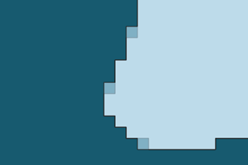

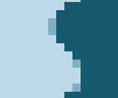

- Step #2: Creating perfectly complementary abyssal and bathyal layers, by taking the difference between the two layers. All grid cells that are shared between the abyssal and bathyal habitats will be associated with the bathyal layer, because they may represent more potential habitat than abyssal areas.

  Operation: merging layers of the two shapefiles to form one deep sea shapefile

  `QGIS: Vector → Data Management Tools → Merge layers → Input Layers: ABYSSAL + BATHYAL` `ArcGIS: Merge, input = p4s2, input = GOODSprovinces_bathyal_irregularities, output = GOODSprovinces_p4s3`
- Step #4: Correcting invalid geometry manually

[figure not shown]

## Part 5: Merging the coastal and deep sea shapefile layers

- Step #1: Here, two options are possible: (i) removing marine ecoregion areas and keeping them associated with the deep-sea layers (ii) removing areas from the deep sea areas and keeping them associated with the ecoregions.

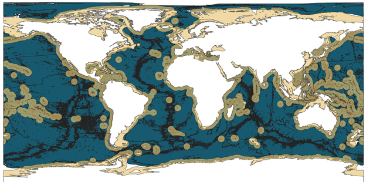

  Operation (i): geometric difference between the MEOW layer and the DEEPSEA layer

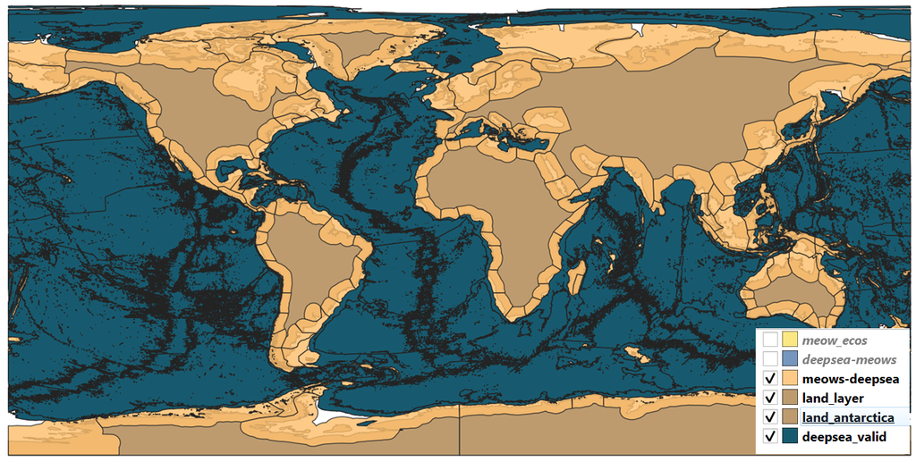

  `QGIS: Vector → Geoprocessing Tools → Difference → Input Layer: MEOW, Overlay Layer: DEEPSEA` `ArcGIS: Geoprocessing → Pairwise Erase, input = meows_ecos, erase = GOODSprovinces_p4s3, output = provinces_p5s1`
- Step #2: Creating a shapefile for joining the layers MEOW and DEEPSEA that after step#1 should be perfectly complementary (no spatial overlap) that I will then call the SEAFLOOR shapefile layer.

  `QGIS: Vector → Data Management Tools → Merge Vector Layers → Input Layers: MEOWS-DEEPSEA, DEEPSEA`

  `ArcGIS: Geoprocessing → Merge, input = provinces_p5s1, input = GOODSprovinces_p4s3, output = provinces_p5s2`
- Step #3: extract provinces_p5s2 as a shapefile
- Step #4: fix the format of provinces_p5s2 in R

```r
# load libraries
library(sf)
library(tidyverse)
library(ggplot2)
library(rgdal)
library(fasterize)
sf::sf_use_s2(FALSE)

# loadlayer after 1st processing on Arc
eco <- st_read("outputs/arcpro/post-processing_1/Provinces_P5S2.shp") %>%
  mutate(type = case_when(MERGE_SRC == "provinces_p5s1" ~ "coastal",
                          MERGE_SRC == "p4s2" ~ "abyssal",
                          MERGE_SRC == "GOODSprovinces_bathyal_Rfix_irregularities" ~ "bathyal"),
         prov_n = PROVINCE,
         prov_id = PROV_CODE,
         prov_id = ifelse(type %in% c("abyssal", "bathyal"), PROVINCE, prov_id),
         prov_n = ifelse(type %in% c("abyssal","bathyal"), Name, prov_n),
         eco_n = ECOREGION,
         eco_id = ECO_CODE,
         rlm_id = RLM_CODE,
         rlm_n = REALM) %>%
  select(ID, type, prov_n, prov_id, eco_n, eco_id, rlm_n, rlm_id)

st_write(eco, dsn = "outputs/bpow/bpow_p5s4.shp")
```

## Part 6: Identify remaining areas

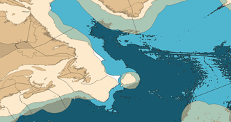

[figure not shown]

- Step #2: get a shapefile with all missing polygons: (merge of seafloor shapefile with a low resolution land layer (does not matter since meows have a bunch of land areas already)

- Step #3: get polygons that are uncharacterized

  | `-ArcGIS: Create feature, extent of -180;180;-90,90` `-ArcGIS: Pairwise erase, input = extent, erase = Provinces_P5S2_PairwiseErase, output = holes_p6s2` |
  | --- |

## Part 7: Remove hadal and classify provinces

```r
# load libraries
library(sf)
library(tidyverse)
library(ggplot2)
library(raster)
library(exactextractr)
library(rgdal)
library(fasterize)
sf::sf_use_s2(FALSE)
library(units)
library(ggtern)
library(rnaturalearth)
library(rnaturalearthdata)
library(tricolore)
library(ggtern)
world <- ne_countries(scale = "medium", returnclass = "sf")
library(tiff)
library(RColorBrewer)
library(egg)

### Libraries
library(raster)
library(geosphere)
library(fasterize)
library(smoothie)
library(exactextractr)


# load biogeography layer
eco <- st_read("outputs/arcpro/post-processing_1/Provinces_P5S2.shp") %>%
  mutate(prov_n = case_when(ID=="1" ~ "Arctic Basin",
                            ID=="2" ~ "North Atlantic",
                            ID=="3" ~ "Brazil Basin",
                            ID=="4" ~ "Angola, Guinea, Sierra Leone Basins",
                            ID=="5" ~ "Argentine Basin",
                            ID=="6" ~ "Antarctica Basin",
                            ID=="7" ~ "Antarctica West",
                            ID=="8" ~ "Indian",
                            ID=="9" ~ "Chile, Peru, Guatemala Basins",
                            ID=="10" ~ "South Pacific",
                            ID=="11" ~ "Equatorial Pacific",
                            ID=="12" ~ "North Central Pacific",
                            ID=="13" ~ "North Pacific",
                            ID=="14" ~ "West Pacific Basins",
                            ID=="15" ~ "Arctic",
                            ID=="16" ~ "Northern Atlantic Boreal",
                            ID=="17" ~ "Northern Pacific Boreal",
                            ID=="18" ~ "North Atlantic",
                            ID=="19" ~ "Southeast Pacific Ridges",
                            ID=="20" ~ "New Zealand-Kermadec",
                            ID=="21" ~ "Cocos Plate",
                            ID=="22" ~ "Nazca Plate",
                            ID=="23" ~ "Antarctic",
                            ID=="24" ~ "Subantarctic",
                            ID=="25" ~ "Indian",
                            ID=="26" ~ "West Pacific",
                            ID=="27" ~ "South Pacific",
                            ID=="28" ~ "North Pacific"))

meow <- st_read("data/meow_ecos/meow_ecos.shp") %>%
  st_drop_geometry() %>%
  dplyr::select(ECOREGION, ECO_CODE_X)

eco$eco_n[1:28] <- "NA"
eco$eco_id[1:28] <- NA
eco <- left_join(eco, meow, by = c("eco_id" = "ECO_CODE_X")) %>%
  mutate(eco_n = ifelse(!is.na(ECOREGION),ECOREGION,NA_character_)) %>%
  dplyr::select(!ECOREGION)


holes <- st_read(dsn = "~/Yale University/Marine Biogeography/outputs/SeafloorMeowsANDNELandHoles", layer = "SeafloorMeowsANDNELandHoles")
eco <- st_transform(eco, crs = st_crs(holes))
rm(holes)

# Load all depth shapefiles
depth_n0_s90_w180_e90 <- raster("data/gebco_2020_ascii/gebco_2020_n0.0_s-90.0_w-180.0_e-90.0.asc")
depth_n0_s90_w90_e0 <- raster("data/gebco_2020_ascii/gebco_2020_n0.0_s-90.0_w-90.0_e0.0.asc")
depth_n0_s90_w0_e90 <- raster("data/gebco_2020_ascii/gebco_2020_n0.0_s-90.0_w0.0_e90.0.asc")
depth_n0_s90_w90_e180 <- raster("data/gebco_2020_ascii/gebco_2020_n0.0_s-90.0_w90.0_e180.0.asc")
depth_n90_s0_w180_e90 <- raster("data/gebco_2020_ascii/gebco_2020_n90.0_s0.0_w-180.0_e-90.0.asc")
depth_n90_s0_w90_e0 <- raster("data/gebco_2020_ascii/gebco_2020_n90.0_s0.0_w-90.0_e0.0.asc")
depth_n90_s0_w0_e90 <- raster("data/gebco_2020_ascii/gebco_2020_n90.0_s0.0_w0.0_e90.0.asc")
depth_n90_s0_w90_e180 <- raster("data/gebco_2020_ascii/gebco_2020_n90.0_s0.0_w90.0_e180.0.asc")

obj = c('depth_n90_s0_w180_e90', 'depth_n90_s0_w90_e0',
        'depth_n90_s0_w0_e90', 'depth_n90_s0_w90_e180',
        "depth_n0_s90_w180_e90", "depth_n0_s90_w90_e0",
        'depth_n0_s90_w0_e90', 'depth_n0_s90_w90_e180')
x.min = c(-180, -90, 0, 90, -180, -90, 0, 90)
x.max = c(-90, 0, 90, 180, -90, 0, 90, 180)
y.min = c(0, 0, 0, 0, -90, -90, -90, -90)
y.max = c(90, 90, 90, 90, 0, 0, 0, 0)

depth_files <- data.frame(obj) %>%
  mutate(xmin = x.min,
         xmax = x.max,
         ymin = y.min,
         ymax = y.max)
select_files_r <- raster(nrows = 2, ncols = 4, xmn = -180, xmx = 180,
                         ymn = -90, ymx = 90) %>%
  rasterToPolygons() %>%
  st_as_sf()


################################################################################
#### Remove hadal regions
################################################################################
eco_no_hadal <- eco
hadal_ecoregions <- c(74,75,76,79,81,82,91,92,93,139,147,148,150,151,153,155,159,163,164,
                      174,175,176,185,195,204,205,223,247)
had_n <- data.frame(c("Sunda Java Trench",
                      "Philippine Trench",
                      "Marianas Trench",
                      "Japan Trench",
                      "Kurile-Kamchatka Trench",
                      "Aleutian Trench",
                      "Tonga Trench",
                      "Kermadec Trench",
                      "Middle America Trench",
                      "Cayman Trench",
                      "Puerto Rico Trench",
                      "Peru-Chile Trench",
                      "South-Sandwich Trench",
                      "Papua Deep",
                      "Indonesia Deep",
                      "Vanuatu Deep",
                      "Izu-Bonin Trench"))
hadal <- data.frame(had_n) %>%
  mutate(type = "hadal",
         ID = c(261:277),
         prov_n = NA_character_,
         prov_id = NA,
         eco_n = NA_character_,
         eco_id = NA,
         rlm = NA_character_,
         rlm_id = NA,
         had_id = c(1:17))%>%
  rename(had_n = `c..Sunda.Java.Trench....Philippine.Trench....Marianas.Trench...`)

# load("creating_layer/remove_hadal_from_coastal.RData")
# ggplot(eco[hadal_ecoregions,]) + geom_sf(color = NA) + theme_bw() +
#   geom_sf(data = eco[hadal_ecoregions[1],], fill = "red", color= NA)

for(h in 1:length(hadal_ecoregions)){

  print(h)
  hadal_one <- eco[hadal_ecoregions[h],]

  # extract lat/long boundaries
  bbox_one <- st_bbox(hadal_one)
```

```r
  bbox_r <- raster(nrow=1, ncol=1, xmn = bbox_one[1], xmx = bbox_one[3],
                   ymn = bbox_one[2], ymx = bbox_one[4])

  overlap_rr <- coverage_fraction(bbox_r, select_files_r)
  select_depth <- c()
  for(r in 1:8){
    if(values(overlap_rr[[r]])==1){select_depth[length(select_depth)+1] <- depth_files$obj[r]}
    if(values(overlap_rr[[r]])>0 && values(overlap_rr[[r]]<1)){select_depth[length(select_depth)+1] <- depth_files$obj[r]}
  }

  if(length(select_depth)>1){
    for(k in 1:length(select_depth)){
      depth_k <- crop(get(select_depth[k]), y = extent(bbox_one[1],bbox_one[3],bbox_one[2],bbox_one[4]))
      if(k==1){depth <- depth_k}
      else{depth <- merge(depth, depth_k)}
      rm(depth_k)
    }
  }
  if(length(select_depth)==1){
    depth <- crop(get(select_depth), y = extent(bbox_one[1],bbox_one[3],bbox_one[2],bbox_one[4]))
  }

  depth_poly <- exact_extract(depth, hadal_one, include_xy = T)

  new_r <- aggregate(depth, fact = 4, fun = min)
  new_r[new_r>(-2000)] <- NA

  overlap_ri <- coverage_fraction(new_r, hadal_one)[[1]]
  overlap_ri[overlap_ri==0] <- NA
  overlap_ri[overlap_ri>0] <- 1
  new_ri <- new_r*overlap_ri
  new_poly <- rasterToPolygons(new_ri)
  new_poly <- st_as_sf(new_poly, crs = st_crs(eco)) %>%
    mutate(ID = 1) %>%
    group_by(ID) %>%
    summarize(geometry = st_union(geometry))

  # ggplot(hadal_one) + geom_sf() + theme_bw() +
  #   geom_sf(data = new_poly, fill = "red", alpha = 0.5)
  # ggplot(new_poly) + geom_sf()

  corr_poly <- st_difference(hadal_one, new_poly)

  #ggplot(corr_poly) + geom_sf()

  # modify coastal ecoregion
  st_geometry(eco_no_hadal[hadal_ecoregions[h],]) <- st_geometry(corr_poly)

  # add geometry of hadal region
  if(hadal_ecoregions[h]==74){
    new_poly <- new_poly %>%
      st_cast(to = "POLYGON")
    poly_1 <- new_poly %>%
      group_by(row.names(new_poly)) %>%
      mutate(lon = st_bbox(geometry)[3]) %>%
      filter(lon<163.1) %>%
      group_by(ID) %>%
      summarize(geometry = st_union(geometry)) %>%
      dplyr::select(-ID)
    poly_1 <- data.frame(c(hadal[5,],poly_1))

    poly_2 <- new_poly %>%
      st_cast(to = "POLYGON") %>%
      group_by(row.names(new_poly)) %>%
      mutate(lon = st_bbox(geometry)[3]) %>%
      filter(lon>163.1) %>%
      group_by(ID) %>%
      summarize(geometry = st_union(geometry)) %>%
      dplyr::select(-ID)
    poly_2 <- data.frame(c(hadal[6,],poly_2))

    hadal_poly <- rbind(poly_1, poly_2)
    rm(poly_1, poly_2)
  } else if (hadal_ecoregions[h] %in% c(139,147,148)){
    new_poly <- new_poly %>%
      dplyr::select(-ID)
    hadal_poly <- rbind(hadal_poly, data.frame(c(hadal[1,], new_poly)))
  } else if (hadal_ecoregions[h] == 155){
    new_poly <- new_poly %>%
      dplyr::select(-ID)
    hadal_poly <- rbind(hadal_poly, data.frame(c(hadal[2,], new_poly)))
  } else if (hadal_ecoregions[h] %in% c(151,153)){
    new_poly <- new_poly %>%
      dplyr::select(-ID)
    hadal_poly <- rbind(hadal_poly, data.frame(c(hadal[3,], new_poly)))
  } else if (hadal_ecoregions[h]==76){
    new_poly <- new_poly %>%
      dplyr::select(-ID)
    hadal_poly <- rbind(hadal_poly, data.frame(c(hadal[4,], new_poly)))
  } else if (hadal_ecoregions[h]==75){
    new_poly <- new_poly %>%
      dplyr::select(-ID)
    hadal_poly <- rbind(hadal_poly, data.frame(c(hadal[5,], new_poly)))
  } else if (hadal_ecoregions[h] %in% c(81,82)){
    new_poly <- new_poly %>%
      dplyr::select(-ID)
    hadal_poly <- rbind(hadal_poly, data.frame(c(hadal[6,], new_poly)))
  } else if (hadal_ecoregions[h] %in% c(174,175,185)){
    new_poly <- new_poly %>%
      dplyr::select(-ID)
    hadal_poly <- rbind(hadal_poly, data.frame(c(hadal[7,], new_poly)))
  } else if (hadal_ecoregions[h] ==223){
    new_poly <- new_poly %>%
      dplyr::select(-ID)
    hadal_poly <- rbind(hadal_poly, data.frame(c(hadal[8,], new_poly)))
  } else if (hadal_ecoregions[h] == 195){
    new_poly <- new_poly %>%
      dplyr::select(-ID)
    hadal_poly <- rbind(hadal_poly, data.frame(c(hadal[9,], new_poly)))
  } else if (hadal_ecoregions[h] ==93){
    new_poly <- new_poly %>%
      dplyr::select(-ID)
    hadal_poly <- rbind(hadal_poly, data.frame(c(hadal[10,], new_poly)))
  } else if (hadal_ecoregions[h] %in% c(91,92)){
    new_poly <- new_poly %>%
      dplyr::select(-ID)
    hadal_poly <- rbind(hadal_poly, data.frame(c(hadal[11,], new_poly)))
  } else if (hadal_ecoregions[h] %in% c(204,205)){
    new_poly <- new_poly %>%
      dplyr::select(-ID)
    hadal_poly <- rbind(hadal_poly, data.frame(c(hadal[12,], new_poly)))
  } else if (hadal_ecoregions[h] ==247){
    new_poly <- new_poly %>%
      dplyr::select(-ID)
    hadal_poly <- rbind(hadal_poly, data.frame(c(hadal[13,], new_poly)))
  } else if (hadal_ecoregions[h] %in% c(163,164)){
    new_poly <- new_poly %>%
      dplyr::select(-ID)
    hadal_poly <- rbind(hadal_poly, data.frame(c(hadal[14,], new_poly)))
  } else if (hadal_ecoregions[h] == 159){
    new_poly <- new_poly %>%
      dplyr::select(-ID)
    hadal_poly <- rbind(hadal_poly, data.frame(c(hadal[15,], new_poly)))
  } else if (hadal_ecoregions[h] == 176){
    new_poly <- new_poly %>%
      dplyr::select(-ID)
    hadal_poly <- rbind(hadal_poly, data.frame(c(hadal[16,], new_poly)))
  } else if (hadal_ecoregions[h] %in% c(79,150)){
    new_poly <- new_poly %>%
      dplyr::select(-ID)
    hadal_poly <- rbind(hadal_poly, data.frame(c(hadal[17,], new_poly)))
  }

  save.image("creating_layer/remove_hadal_from_coastal.RData")

  rm(corr_poly, new_poly, overlap_ri, depth_poly, depth, new_ri, new_r,
     select_depth, overlap_rr, bbox_r, bbox_one, hadal_one)
}

load("creating_layer/remove_hadal_from_coastal.RData")

eco_hadal <- st_make_valid(eco_no_hadal) %>%
  dplyr::select(-Shape_Area, -Shape_Leng, -Regions, -percent) %>%
  mutate(had_id = NA,
         had_n = NA_character_) %>%
  dplyr::select(type, prov_n, prov_id, eco_n, eco_id, rlm_n, rlm_id, ID, had_id, had_n, geometry)

hadal_poly <- st_make_valid(st_as_sf(hadal_poly)) %>%
  rename(rlm_n = rlm) %>%
  group_by(type, prov_n, prov_id, eco_n, eco_id, rlm_n, rlm_id, ID, had_id, had_n) %>%
  summarize(geometry = st_union(geometry)) %>%
  dplyr::select(type, prov_n, prov_id, eco_n, eco_id, rlm_n, rlm_id, ID, had_id, had_n, geometry)
```

```r
eco_hadal <- rbind(eco_hadal, hadal_poly)

st_write(obj = eco_hadal,
         dsn = "~/Yale University/Marine Biogeography/outputs/remove_hadal/seafloor_meow_deepsea_w_hadal_18_10_2021.shp")
```

## Part 8: Characterize missing regions

```r
###############################################################################
#### Set up marine regions for the whole ocean sea floor
#### Code to characterize missing regions and associate a polygon to them
#### Coding and data processing: Aurore Maureaud
#### July 2022
################################################################################

rm(list = ls())

### Libraries
library(sf)
library(tidyverse)
library(ggplot2)
library(rgdal)
library(RColorBrewer)
library(raster)
library(geosphere)
library(fasterize)
library(smoothie)
library(exactextractr)
library(Morpho)
library(rgl)
library(units)


################################################################################
### Load data & fix shapefile attributes
################################################################################
# Load seafloor shapefile = meows-deepsea
seafloor_meow_deepsea <- st_read(dsn = "outputs/seafloor", layer = "seafloor_meows-deepsea") %>%
  mutate(type = case_when(layer=="abyssal_fixbathyal_Rfix" ~ "abyssal",
                          layer=="GOODSprovinces_bathyal_Rfix" ~ "bathyal",
                          is.na(layer) ~ "MEOW"),
         meow_prov_name = ifelse(str_detect(Province, "[a-z]")==TRUE,Province,NA),
         abyssal_id = ifelse(str_detect(Province, "[a-z]")==FALSE & type=="abyssal",Province,NA),
         bathyal_id = ifelse(str_detect(Province, "[a-z]")==FALSE & type=="bathyal",Province,NA),
         abyssal_name = case_when(abyssal_id=="1" ~ "Arctic Basin",
                                  abyssal_id=="2" ~ "North Atlantic",
                                  abyssal_id=="3" ~ "Brazil Basin",
                                  abyssal_id=="4" ~ "Angola, Guinea, Sierra Leone Basins",
                                  abyssal_id=="5" ~ "Argentine Basin",
                                  abyssal_id=="6" ~ "Antarctica Basin",
                                  abyssal_id=="7" ~ "Antarctica West",
                                  abyssal_id=="8" ~ "Indian",
                                  abyssal_id=="9" ~ "Chile, Peru, Guatemala Basins",
                                  abyssal_id=="10" ~ "South Pacific",
                                  abyssal_id=="11" ~ "Equatorial Pacific",
                                  abyssal_id=="12" ~ "North Central Pacific",
                                  abyssal_id=="13" ~ "North Pacific",
                                  abyssal_id=="14" ~ "West Pacific Basins",
                                  is.na(abyssal_id) ~ "NA"),
         bathyal_name = case_when(bathyal_id=="1" ~ "Arctic",
                                  bathyal_id=="2" ~ "Northern Atlantic Boreal",
                                  bathyal_id=="3" ~ "Northern Pacific Boreal",
                                  bathyal_id=="4" ~ "North Atlantic",
                                  bathyal_id=="5" ~ "Southeast Pacific Ridges",
                                  bathyal_id=="6" ~ "New Zealand-Kermadec",
                                  bathyal_id=="7" ~ "Cocos Plate",
                                  bathyal_id=="8" ~ "Nazca Plate",
                                  bathyal_id=="9" ~ "Antarctic",
                                  bathyal_id=="10" ~ "Subantarctic",
                                  bathyal_id=="11" ~ "Indian",
                                  bathyal_id=="12" ~ "West Pacific",
                                  bathyal_id=="13" ~ "South Pacific",
                                  bathyal_id=="14" ~ "North Pacific",
                                  is.na(bathyal_id) ~ "NA")) %>%
  rename(meow_eco_id = ECO_CODE_X,
         meow_prov_id = PROV_CODE,
         meow_rlm_id = RLM_CODE,
         meow_eco_name = ECOREGION,
         meow_rlm_name = REALM,
         deepsea_prov_id = ID) %>%
  dplyr::select(-path, -layer, -ALT_CODE, -ECO_CODE, -Lat_Zone, -Name, -Province)
seafloor_meow_deepsea$ID <- c(1:nrow(seafloor_meow_deepsea))


# Load holes shapefile - done by Griffy Vigneron from the low res land layer and the seafloor_meows_deepsea layer
# with news polygons missing last time + removed odd lines
holes <- st_read(dsn = "outputs/SeafloorMeowsANDNELandHoles", layer = "SeafloorMeowsANDNELandHoles")
holes <- holes %>%
  st_cast("POLYGON") %>%
  mutate(ID = c(1:nrow(holes)),
         Shape_Area = drop_units(st_area(geometry)),
         Shape_Leng = drop_units(st_length(geometry))) %>%
  dplyr::select(-Id) %>%
  filter(!ID %in% c(1713,2210)) # remove arctic polygon, as well as Caspian sea
# there are 2210 holes corresponding to uncharacterized regions

# Load all depth shapefiles
depth_n0_s90_w180_e90 <- raster("data/gebco_2020_ascii/gebco_2020_n0.0_s-90.0_w-180.0_e-90.0.asc")
depth_n0_s90_w90_e0 <- raster("data/gebco_2020_ascii/gebco_2020_n0.0_s-90.0_w-90.0_e0.0.asc")
depth_n0_s90_w0_e90 <- raster("data/gebco_2020_ascii/gebco_2020_n0.0_s-90.0_w0.0_e90.0.asc")
depth_n0_s90_w90_e180 <- raster("data/gebco_2020_ascii/gebco_2020_n0.0_s-90.0_w90.0_e180.0.asc")
depth_n90_s0_w180_e90 <- raster("data/gebco_2020_ascii/gebco_2020_n90.0_s0.0_w-180.0_e-90.0.asc")
depth_n90_s0_w90_e0 <- raster("data/gebco_2020_ascii/gebco_2020_n90.0_s0.0_w-90.0_e0.0.asc")
depth_n90_s0_w0_e90 <- raster("data/gebco_2020_ascii/gebco_2020_n90.0_s0.0_w0.0_e90.0.asc")
depth_n90_s0_w90_e180 <- raster("data/gebco_2020_ascii/gebco_2020_n90.0_s0.0_w90.0_e180.0.asc")

obj = c('depth_n90_s0_w180_e90', 'depth_n90_s0_w90_e0',
        'depth_n90_s0_w0_e90', 'depth_n90_s0_w90_e180',
        "depth_n0_s90_w180_e90", "depth_n0_s90_w90_e0",
        'depth_n0_s90_w0_e90', 'depth_n0_s90_w90_e180')
x.min = c(-180, -90, 0, 90, -180, -90, 0, 90)
x.max = c(-90, 0, 90, 180, -90, 0, 90, 180)
y.min = c(0, 0, 0, 0, -90, -90, -90, -90)
y.max = c(90, 90, 90, 90, 0, 0, 0, 0)

depth_files <- data.frame(obj) %>%
  mutate(xmin = x.min,
         xmax = x.max,
         ymin = y.min,
         ymax = y.max)
select_files_r <- raster(nrows = 2, ncols = 4, xmn = -180, xmx = 180,
                         ymn = -90, ymx = 90) %>%
  rasterToPolygons() %>%
  st_as_sf()
```

```r
################################################################################
### Loop to correct for missing areas
################################################################################
# <- seafloor_meow_deepsea
#problems <- c()

# try for h=382
# problem at h=35, 89, 161, 174, 189, 265, 395, 419
#problems <- c(35,89,161,174,189,265,395,419,693,694,695,696,
#              701)
#load("outputs/fill_holes/results_fill_holes.RData")

load("outputs/fill_holes/envt_2.RData")

for(h in 1530:nrow(holes)){
  print(h)

  hole_one <- holes[h,]

  # extract lat/long boundaries
  bbox_one <- st_bbox(hole_one)

  # create bounding box for the raster shapefile & polygons
  x_range <- abs(abs(bbox_one$xmax) - abs(bbox_one$xmin))
  y_range <- abs(abs(bbox_one$ymax) - abs(bbox_one$ymin))
  new_bbox <- as.vector(bbox_one)
  new_bbox[1] <- new_bbox[1] -0.1*x_range
  new_bbox[2] <- new_bbox[2] -0.1*y_range
  new_bbox[3] <- new_bbox[3] +0.1*x_range
  new_bbox[4] <- new_bbox[4] +0.1*y_range

  if(new_bbox[1]<(-180)){new_bbox[1] <- (-180)}
  if(new_bbox[2]<(-90)){new_bbox[2] <- (-90)}
  if(new_bbox[3]>180){new_bbox[3] <- 180}
  if(new_bbox[4]>90){new_bbox[4] <- 90}

  # get the depth raster(s) around that zone
  # intersect between the new_bbox and the select files
  new_bbox_r <- raster(nrow=1, ncol=1, xmn = new_bbox[1], xmx = new_bbox[3],
                       ymn = new_bbox[2], ymx = new_bbox[4])

  overlap_rr <- coverage_fraction(new_bbox_r, select_files_r)
  select_depth <- c()
  for(r in 1:8){
    if(values(overlap_rr[[r]])==1){select_depth[length(select_depth)+1] <- depth_files$obj[r]}
    if(values(overlap_rr[[r]])>0 && values(overlap_rr[[r]]<1)){select_depth[length(select_depth)+1] <- depth_files$obj[r]}
  }

  # extract the zone around the bbox from the raster
  if(length(select_depth)>0){
    if(length(select_depth)>1){
      for(k in 1:length(select_depth)){
        depth_k <- crop(get(select_depth[k]), y = extent(new_bbox[1],new_bbox[3],new_bbox[2],new_bbox[4]))
        if(k==1){depth <- depth_k}
        else{depth <- merge(depth, depth_k)}
        rm(depth_k)
      }
    }
    if(length(select_depth)==1){
      depth <- crop(get(select_depth), y = extent(new_bbox[1],new_bbox[3],new_bbox[2],new_bbox[4]))
    }

    while((dim(depth)[1]*dim(depth)[2])<10){
      new_bbox[1] <- new_bbox[1] -0.3*x_range
      new_bbox[2] <- new_bbox[2] -0.3*y_range
      new_bbox[3] <- new_bbox[3] +0.3*x_range
      new_bbox[4] <- new_bbox[4] +0.3*y_range
      if(length(select_depth)>1){
        for(k in 1:length(select_depth)){
          depth_k <- crop(get(select_depth[k]), y = extent(new_bbox[1],new_bbox[3],new_bbox[2],new_bbox[4]))
          if(k==1){depth <- depth_k}
          if(k>1){depth <- merge(depth, depth_k)}
          rm(depth_k)
        }
      }
      if(length(select_depth)==1){
        depth <- crop(get(select_depth), y = extent(new_bbox[1],new_bbox[3],new_bbox[2],new_bbox[4]))
      }
    }

    # print final dimensions
    print(dim(depth)[1]*dim(depth)[2])

    # extract necessary polygons
    depth_spdf <- as(depth, "SpatialPixelsDataFrame")
    depth_df <- as.data.frame(depth_spdf)
    colnames(depth_df) <- c("depth", "x", "y")

    # select polygons from shapefile and depth raster
    depth_pts <- data.frame(rasterToPoints(depth))
    depth_pts_sf <- st_as_sf(depth_pts, coords = c("x","y"), crs = st_crs(seafloor_meow_deepsea))
    select_polygons <- st_intersects(depth_pts_sf, seafloor_meow_deepsea)
    select_polygons <- unique(unlist(select_polygons))
    select_polygons <- seafloor_meow_deepsea[select_polygons,]

    if(nrow(select_polygons)==1){
      new_poly <- select_polygons %>% st_drop_geometry()
      st_geometry(new_poly) <- st_geometry(holes[h,])
      seafloor_meow_deepsea_filled <- rbind(seafloor_meow_deepsea_filled, new_poly)
      save(seafloor_meow_deepsea_filled, file="outputs/fill_holes/results_fill_holes_2.RData")
      save.image("outputs/fill_holes/envt_2.RData")
      rm(new_poly)
      print("One polygon")
    }

    if(nrow(select_polygons)>1 && dim(depth)[2]==1){
      new_poly <- select_polygons[1,] %>% st_drop_geometry()
      st_geometry(new_poly) <- st_geometry(holes[h,])
      seafloor_meow_deepsea_filled <- rbind(seafloor_meow_deepsea_filled, new_poly)
      save(seafloor_meow_deepsea_filled, file="outputs/fill_holes/results_fill_holes_2.RData")
      save.image("outputs/fill_holes/envt_2.RData")
      rm(new_poly)
      print("Column polygon")}

    if(nrow(select_polygons)>1 && dim(depth)[2]>1){
      select_polygons_merged <- st_union(select_polygons) # a bit long to run, only 3 polygons
      xx <- coverage_fraction(depth, select_polygons_merged)

      depths_empty <- as.data.frame(as(xx[[1]], "SpatialPixelsDataFrame")) %>%
        rename(coverage = layer) %>%
        filter(coverage<1) %>%
        left_join(depth_pts, by=c('x','y'))

      depths_full <- as.data.frame(as(xx[[1]], "SpatialPixelsDataFrame")) %>%
        rename(coverage = layer) %>%
        filter(coverage==1) %>%
        left_join(depth_pts, by=c('x','y'))

      # query will be depth_pts_empty transformed in 3D matrix
      depth_pts_empty_df <- depths_empty %>%
        rename(z = names(depths_empty)[4]) %>%
        mutate(z = z) %>%
        dplyr::select(x,y,z)
      depth_pts_empty_mat <- data.matrix(depth_pts_empty_df)

      # target will be depth_pts transformed in 3D matrix
      depth_pts_df <- depths_full %>%
        rename(z = names(depths_empty)[4]) %>%
        mutate(z = z) %>%
        dplyr::select(x,y,z)
      depth_pts_mat <- data.matrix(depth_pts_df)

      # try out the function on depth example
      xx <- mcNNindex(target = depth_pts_mat, query = depth_pts_empty_mat, k=1)
      depth_pts_empty_closest <- data.frame(cbind(depth_pts_empty_mat, xx)) %>%
        mutate(x_closest = NA,
               y_closest = NA,
               poly = NA_character_)

      types <- c(select_polygons$ID)
      pts <- st_as_sf(depth_pts_df, coords = c("x","y"), crs= st_crs(select_polygons))
      tt <- unlist(st_intersects(pts, select_polygons, sparse=T))
```

```r
      for(i in 1:nrow(depth_pts_empty_closest)){
        # assign closest coords
        depth_pts_empty_closest$x_closest[i] <- depth_pts_df$x[depth_pts_empty_closest$V4[i]]
        depth_pts_empty_closest$y_closest[i] <- depth_pts_df$y[depth_pts_empty_closest$V4[i]]
        # assign polygon
        depth_pts_empty_closest$poly[i] <- types[tt[[depth_pts_empty_closest$V4[i]]]]
      }

      # rasterize the closest points and aggregate a higher scale
      # create new grid with lower resolution
      # same for rasters
      new_r <- aggregate(depth, fact = 4, fun = mean)

      overlap_ri <- coverage_fraction(new_r, holes[h,])[[1]]
      overlap_ri[overlap_ri==0] <- NA
      overlap_ri[overlap_ri>0] <- 1
      new_ri <- new_r*overlap_ri

      new_poly <- rasterToPolygons(new_ri)
      new_poly <- st_as_sf(new_poly, crs = st_crs(seafloor_meow_deepsea_filled))
      new_poly$ID <- c(1:nrow(new_poly))

      depth_pts_empty_closest_sf <- st_as_sf(depth_pts_empty_closest, coords = c('x','y'),
                                             crs = st_crs(new_poly))
      new_poly_closest <- st_join(new_poly, depth_pts_empty_closest_sf, left=T) %>%
        st_drop_geometry() %>%
        group_by(ID, poly) %>% summarise(n=length(poly)) %>% slice_max(n, with_ties = FALSE)

      new_poly <- left_join(new_poly, new_poly_closest, by = "ID") %>%
        filter(n>0) %>%
        group_by(poly) %>%
        summarize(geometry = st_union(geometry))

      # get attributes from seafloor shapefile
      select_polygons <- select_polygons %>%
        filter(ID %in% new_poly$poly) %>%
        st_drop_geometry()
      new_poly <- new_poly %>%
        mutate(poly = as.numeric(as.vector(poly)))
      new_poly <- left_join(select_polygons, new_poly, by=c("ID"="poly"))
      new_poly <- st_as_sf(new_poly, crs = st_crs(seafloor_meow_deepsea_filled))
      seafloor_meow_deepsea_filled <- rbind(seafloor_meow_deepsea_filled,new_poly)

      save(seafloor_meow_deepsea_filled, file="outputs/fill_holes/results_fill_holes_2.RData")
      save.image("outputs/fill_holes/envt_2.RData")
      print("Multi polygons")

      rm(new_poly, new_poly_closest, new_r, new_ri, types, depth_pts_empty_closest,
         depth_pts_empty_df, depth_pts_empty_mat,
         depths_empty, depths_full,select_polygons_merged,
         xx, depth_pts_mat)

    }

    rm(depth_pts, depth_pts_sf, select_polygons, depth_spdf, depth_df, depth,
       overlap_rr, new_bbox_r, select_depth, new_bbox, x_range, y_range, hole_one,
       bbox_one)

  }

  else{problems[length(problems)+1] <- h
  print("length(select_depth) not positive")
  save.image("outputs/fill_holes/envt_2.RData")}

}



### PLOTS
# plot polygons
ggplot() + geom_sf(data = hole_one, fill="grey") + theme_bw() +
  geom_sf(data = select_polygons, aes(fill=as.factor(ID))) +
  coord_sf(xlim = c(new_bbox[1], new_bbox[3]), ylim = c(new_bbox[2], new_bbox[4])) +
  coord_sf(xlim = c(min(depth_df$x),max(depth_df$x)), ylim = c(min(depth_df$y), max(depth_df$y)))

# # plots 3D closest polygon
ggplot()+
  geom_point(data = depth_pts_empty_closest, aes(x = x, y = y, colour = poly), size=2) +
  geom_sf(data = seafloor_meow_deepsea, fill=NA, colour="black") +
  coord_sf(xlim = c(min(depth_df$x),max(depth_df$x)), ylim = c(min(depth_df$y), max(depth_df$y)))

# # plot depth
ggplot() + geom_tile(data = depth_df, aes(x=x, y=y, fill = depth)) +
  scale_fill_gradientn(colours = terrain.colors(4)) + theme_bw() +
  geom_sf(data = seafloor_meow_deepsea, fill=NA, colour="black") +
  coord_sf(xlim = c(min(depth_df$x),max(depth_df$x)), ylim = c(min(depth_df$y), max(depth_df$y)))

# # plot smoothed polygons
ggplot() + geom_sf(data = new_r, aes(fill = poly), colour = NA)
ggplot() + geom_sf(data = new_poly, aes(fill = as.factor(ID)), colour = NA) +
  geom_sf(data = seafloor_meow_deepsea, fill=NA, colour="black") +
  coord_sf(xlim = c(min(depth_df$x),max(depth_df$x)), ylim = c(min(depth_df$y), max(depth_df$y)))

ggplot() + geom_sf(data = new_poly, colour = NA, fill="grey") + theme_minimal()+
  geom_sf(data = seafloor_meow_deepsea, fill="black", colour=NA) +
  coord_sf(xlim = c(min(depth_df$x),max(depth_df$x)), ylim = c(min(depth_df$y), max(depth_df$y)))



### Run the loop for problems
load("outputs/fill_holes/envt.RData")
problems_pb <- c()
seafloor_meow_deepsea_filled_pb <- seafloor_meow_deepsea_filled

# for(h in 5:length(problems)){
#   print(h)
#
#   hole_one <- holes %>% filter(ID == holes$ID[problems[h]])
#
#   # extract lat/long boundaries
#   bbox_one <- st_bbox(hole_one)
#
#   # create bounding box for the raster shapefile & polygons
#   x_range <- abs(abs(bbox_one$xmax) - abs(bbox_one$xmin))
#   y_range <- abs(abs(bbox_one$ymax) - abs(bbox_one$ymin))
#   new_bbox <- as.vector(bbox_one)
#   new_bbox[1] <- new_bbox[1] -0.1*x_range
#   new_bbox[2] <- new_bbox[2] -0.1*y_range
#   new_bbox[3] <- new_bbox[3] +0.1*x_range
#   new_bbox[4] <- new_bbox[4] +0.1*y_range
#
#   if(new_bbox[1]<(-180)){new_bbox[1] <- (-180)}
#   if(new_bbox[2]<(-90)){new_bbox[2] <- (-90)}
#   if(new_bbox[3]>180){new_bbox[3] <- 180}
#   if(new_bbox[4]>90){new_bbox[4] <- 90}
#
#   # get the depth raster(s) around that zone
#   # intersect between the new_bbox and the select files
#   new_bbox_r <- raster(nrow=1, ncol=1, xmn = new_bbox[1], xmx = new_bbox[3],
#                        ymn = new_bbox[2], ymx = new_bbox[4])
#
#   overlap_rr <- coverage_fraction(new_bbox_r, select_files_r)
#   select_depth <- c()
#   for(r in 1:8){if(values(overlap_rr[[r]])==1){select_depth[length(select_depth)+1] <- depth_files$obj[r]}
#     if(values(overlap_rr[[r]])>0 & values(overlap_rr[[r]]<1)){select_depth[length(select_depth)+1] <- depth_files$obj[r]}
#     }
#
#   # extract the zone around the bbox from the raster
#   if(length(select_depth)>0){
#     if(length(select_depth)>1){
#       for(k in 1:length(select_depth)){
#         depth_k <- crop(get(select_depth[k]), y = extent(new_bbox[1],new_bbox[3],new_bbox[2],new_bbox[4]))
#         if(k==1){depth <- depth_k}
#         else{depth <- merge(depth, depth_k)}
#       }
#     }
#     if(length(select_depth)==1){
#       depth <- crop(get(select_depth), y = extent(new_bbox[1],new_bbox[3],new_bbox[2],new_bbox[4]))
#     }
#
#     print(dim(depth)[1]*dim(depth)[2])
#
#       # extract necessary polygons
#       depth_spdf <- as(depth, "SpatialPixelsDataFrame")
#       depth_df <- as.data.frame(depth_spdf)
#       colnames(depth_df) <- c("depth", "x", "y")
#
#       # select polygons from shapefile and depth raster
#       depth_pts <- data.frame(rasterToPoints(depth))
#       depth_pts_sf <- st_as_sf(depth_pts, coords = c("x","y"), crs = st_crs(seafloor_meow_deepsea))
#       select_polygons <- st_intersects(depth_pts_sf, seafloor_meow_deepsea)
#       select_polygons <- unique(unlist(select_polygons))
#       select_polygons <- seafloor_meow_deepsea[select_polygons,]
#
#     if(nrow(select_polygons)==1){
#       new_poly <- select_polygons %>% st_drop_geometry()
#       st_geometry(new_poly) <- st_geometry(holes[h,])
#       seafloor_meow_deepsea_filled_pb <- rbind(seafloor_meow_deepsea_filled_pb, new_poly)
#       rm(new_poly)
#     }
#     else if (nrow(select_polygons)>1 && dim(depth)[2]==1){
#       new_poly <- select_polygons[1,] %>% st_drop_geometry()
#       st_geometry(new_poly) <- st_geometry(holes[problems[h],])
#       seafloor_meow_deepsea_filled_pb <- rbind(seafloor_meow_deepsea_filled_pb, new_poly)
#       rm(new_poly)}
#     else if (nrow(select_polygons)>1 && dim(depth)[1]==1){
#       new_poly <- select_polygons[1,] %>% st_drop_geometry()
#       st_geometry(new_poly) <- st_geometry(holes[problems[h],])
#       seafloor_meow_deepsea_filled_pb <- rbind(seafloor_meow_deepsea_filled_pb, new_poly)
#       rm(new_poly)}
#     else if (nrow(select_polygons)==0){print("Caspian Sea")}
#     else{
#       select_polygons_merged <- st_union(select_polygons) # a bit long to run, only 3 polygons
#       xx <- coverage_fraction(depth, select_polygons_merged)
#
#       depths_empty <- as.data.frame(as(xx[[1]], "SpatialPixelsDataFrame")) %>%
#         rename(coverage = layer) %>%
#         filter(coverage<1) %>%
#         left_join(depth_pts, by=c('x','y'))
#
#       depths_full <- as.data.frame(as(xx[[1]], "SpatialPixelsDataFrame")) %>%
#         rename(coverage = layer) %>%
#         filter(coverage==1) %>%
#         left_join(depth_pts, by=c('x','y'))
#
#       # query will be depth_pts_empty transformed in 3D matrix
#       depth_pts_empty_df <- depths_empty %>%
#         rename(z = names(depths_empty)[4]) %>%
#         mutate(z = z) %>%
#         dplyr::select(x,y,z)
#       depth_pts_empty_mat <- data.matrix(depth_pts_empty_df)
#
#       # target will be depth_pts transformed in 3D matrix
#       depth_pts_df <- depths_full %>%
#         rename(z = names(depths_empty)[4]) %>%
#         mutate(z = z) %>%
#         dplyr::select(x,y,z)
#       depth_pts_mat <- data.matrix(depth_pts_df)
#
#       # try out the function on depth example
#       xx <- mcNNindex(target = depth_pts_mat, query = depth_pts_empty_mat, k=1)
#       depth_pts_empty_closest <- data.frame(cbind(depth_pts_empty_mat, xx)) %>%
#         mutate(x_closest = NA,
#                y_closest = NA,
#                poly = NA_character_)
#
#       types <- c(select_polygons$ID)
#       pts <- st_as_sf(depth_pts_df, coords = c("x","y"), crs= st_crs(select_polygons))
#       tt <- unlist(st_intersects(pts, select_polygons, sparse=T))
#
#       for(i in 1:nrow(depth_pts_empty_closest)){
#         # assign closest coords
#         depth_pts_empty_closest$x_closest[i] <- depth_pts_df$x[depth_pts_empty_closest$V4[i]]
#         depth_pts_empty_closest$y_closest[i] <- depth_pts_df$y[depth_pts_empty_closest$V4[i]]
#         # assign polygon
#         depth_pts_empty_closest$poly[i] <- types[tt[[depth_pts_empty_closest$V4[i]]]]
#       }
#
#       # rasterize the closest points and aggregate a higher scale
#       # create new grid with lower resolution
#       # same for rasters
#       if(problems[h] %in% c(395,693,946)){new_r <- depth}
#       else{
#         new_r <- aggregate(depth, fact = 4, fun = mean)
#         }
#       new_ri <- crop(new_r, extent(holes[problems[h],]))
#       new_ri <- mask(new_ri, holes[problems[h],])
#
#       new_poly <- rasterToPolygons(new_ri)
#       new_poly <- st_as_sf(new_poly, crs = st_crs(seafloor_meow_deepsea_filled))
#       new_poly$ID <- c(1:nrow(new_poly))
#
#       depth_pts_empty_closest_sf <- st_as_sf(depth_pts_empty_closest, coords = c('x','y'),
#                                              crs = st_crs(new_poly))
#       new_poly_closest <- st_join(new_poly, depth_pts_empty_closest_sf, left=T) %>%
#         st_drop_geometry() %>%
#         group_by(ID, poly) %>% summarise(n=length(poly)) %>% slice_max(n, with_ties = FALSE)
#
#       new_poly <- left_join(new_poly, new_poly_closest, by = "ID") %>%
#         filter(n>0) %>%
#         group_by(poly) %>%
#         summarize(geometry = st_union(geometry))
#
#       # get attributes from seafloor shapefile
#       select_polygons <- select_polygons %>%
#         filter(ID %in% new_poly$poly) %>%
#         st_drop_geometry()
#       new_poly <- new_poly %>%
#         mutate(poly = as.numeric(as.vector(poly)))
#       new_poly <- left_join(select_polygons, new_poly, by=c("ID"="poly"))
#       new_poly <- st_as_sf(new_poly, crs = st_crs(seafloor_meow_deepsea_filled))
#       seafloor_meow_deepsea_filled_pb <- rbind(seafloor_meow_deepsea_filled_pb,new_poly)
#
#       rm(new_poly, new_poly_closest, new_r, new_ri, types, depth_pts_empty_closest,
#          depth_pts_empty_df, depth_pts_empty_mat,
#          depths_empty, depths_full,select_polygons_merged,
#          xx, depth_pts_mat)
#
#     }
#
#     rm(depth_pts, depth_pts_sf, select_polygons, depth_spdf, depth_df, depth,
#        overlap_rr, new_bbox_r, select_depth, new_bbox, x_range, y_range, hole_one,
#        bbox_one)
#
#     save(seafloor_meow_deepsea_filled_pb, file="outputs/fill_holes/results_fill_holes_problems.RData")
```

```r
#     save.image("outputs/fill_holes/envt_problems.RData")
#   }
#
#   else{problems_pb[length(problems_pb)+1] <- problems[h]
#   save.image("outputs/fill_holes/envt_problems.RData")}
#
# }


################################################################################
### QC & SAVE
################################################################################
### Finalize shapefile
load("outputs/fill_holes/results_fill_holes_problems.RData")
load("outputs/fill_holes/results_fill_holes_2.RData")

seafloor_meow_deepsea_final <- seafloor_meow_deepsea_filled %>%
  group_by(deepsea_prov_id,meow_eco_name,meow_prov_id,meow_rlm_id,meow_rlm_name,
           meow_eco_id,type,meow_prov_name,abyssal_id,bathyal_id,
           abyssal_name,bathyal_name,ID) %>%
  summarize(geometry = st_union(geometry)) %>%
  ungroup()

xx <- st_is_valid(seafloor_meow_deepsea_final) # all true so shapefile valid!

st_write(obj = seafloor_meow_deepsea_final, dsn = "~/Yale University/Marine Biogeography/outputs/fill_holes/seafloor_meow_deepsea_final_2.shp")
st_write(obj = seafloor_meow_deepsea_filled, dsn = "~/Yale University/Marine Biogeography/outputs/fill_holes/seafloor_meow_deepsea_filled_2.shp")

windows()
ggplot() + geom_sf(data = seafloor_meow_deepsea_final, fill="black", colour=NA)
ggplot() + geom_sf(data = seafloor_meow_deepsea, fill="black", colour=NA)

# add holes layers
#holes <- st_read(dsn = "outputs/ClippedAndMergedFiles", layer = "MissingAreas")
land <- st_read(dsn = "regions_base/land/ne_10m_land", layer = "ne_10m_land")
ggplot() +
  geom_sf(data = land, fill="lightgreen", colour=NA) +
  geom_sf(data = seafloor_meow_deepsea_final, fill="black", colour=NA)
ggplot() + geom_sf(data = seafloor_meow_deepsea, fill="black", colour=NA)


# plot all regions
seafloor_meow_deepsea_final <- seafloor_meow_deepsea_final %>%
  mutate(name = coalesce(meow_eco_name, abyssal_name),
         name = coalesce(name, bathyal_name))

ggplot() +
  geom_sf(data = seafloor_meow_deepsea_final, aes(fill = as.factor(name))) +
  theme_bw() + theme(legend.position = "none")

require(RColorBrewer)
jet.colors <- colorRampPalette(c("#00007F", "blue", "#007FFF", "cyan"))

seafloor_meow_deepsea_final %>%
  filter(!is.na(abyssal_name)) %>%
  ggplot() +
  geom_sf(aes(fill = abyssal_id)) +
  theme_bw() + theme(legend.position = "none") +
  scale_fill_gradientn(colours = jet.colors(10),guide = "colourbar")
```

# References

Belyaev, G. M. 1989. *Deep Sea Ocean Trenches and Their Fauna.* Nauka, Moscow.

Group, GEBCO Bathymetric Compilation. 2020. “The GEBCO_2020 Grid - a Continuous Terrain Model of the Global Oceans and Land.” British Oceanographic Data Centre, National Oceanography Centre, NERC, UK. https://doi.org/10.5285/A29C5465-B138-234D-E053-6C86ABC040B9.

Spalding, Mark D., Helen E. Fox, Gerald R. Allen, Nick Davidson, Zach A. Ferdaña, Max Finlayson, Benjamin S. Halpern, et al. 2007. “Marine Ecoregions of the World: A Bioregionalization of Coastal and Shelf Areas.” *BioScience* 57 (7): 573–83. https://doi.org/10.1641/B570707.

Watling, Les, John Guinotte, Malcolm R. Clark, and Craig R. Smith. 2013. “A Proposed Biogeography of the Deep Ocean Floor.” *Progress in Oceanography* 111 (April): 91–112. https://doi.org/10.1016/j.pocean.2012.11.003.